# Mozambique Development Progress (2000 - 2024)

## Poverty Rate

Following the analysis of GDP per capita, it is important to examine how economic performance translates into social outcomes, particularly poverty reduction.

Overall, while significant progress has been made, the pattern suggests that poverty reduction in Mozambique has slowed in recent years and remains sensitive to economic shocks, highlighting the need for more resilient and inclusive growth strategies.

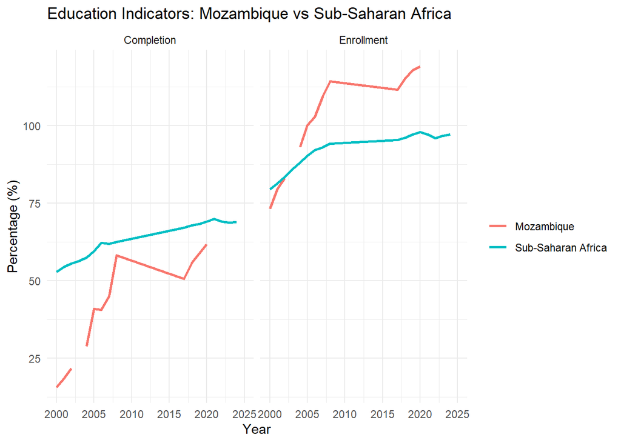

```r
df %>%
  filter(Indicator_short %in% c("Enrollment", "Completion")) %>%
  pivot_longer(
    cols = c(Mozambique, `Sub-Saharan Africa`),
    names_to = "Country",
    values_to = "Value"
  ) %>%
  ggplot(aes(x = Year, y = Value, color = Country)) +
  geom_line(linewidth = 1) +
  facet_wrap(~ Indicator_short) +
  labs(
    title = "Education Indicators: Mozambique vs Sub-Saharan Africa",
    y = "Percentage (%)",
    color = ""
  ) +
  theme_minimal()
```

Education is a key pillar of development, and the comparison between enrollment and completion rates provides important insights into both access to and effectiveness of the education system in Mozambique.

Primary school enrollment in Mozambique shows a strong upward trend from the early 2000s, reaching levels above 100%. This reflects substantial expansion in access to education over time. Enrollment rates above 100% are common in developing countries and indicate the inclusion of over-age and under-age students in the system.

However, completion rates remain consistently lower than enrollment levels, highlighting a persistent gap between access and actual educational outcomes. This indicates that while more children are entering the education system, a considerable proportion does not complete primary education.

Although completion rates improve over time, the gap between enrollment and completion remains evident throughout the period. This pattern suggests ongoing challenges in student retention within the education system.

Overall, the analysis shows that Mozambique has made strong progress in expanding access to education, but still faces challenges in translating access into successful completion.

## Conclusion

This analysis examined key development indicators in Mozambique, focusing on economic performance (GDP per capita), poverty, and education outcomes, with a comparative perspective against Sub-Saharan Africa.

The results highlight that Mozambique has made notable progress in expanding access to education and, to some extent, improving economic conditions over time. However, this progress has not been uniform across all dimensions.

While GDP per capita shows gradual growth, it remains consistently below the regional average, indicating persistent structural economic gaps. Similarly, poverty levels have declined over time, but the pace of reduction appears to have slowed in recent years.

In the education sector, the analysis reveals strong improvements in enrollment, reflecting increased access to schooling. However, completion rates remain significantly lower, indicating challenges in retention and overall education outcomes.

Taken together, these findings suggest that Mozambique has made important strides in development, particularly in expanding access to essential services. However, translating these gains into sustained economic growth and improved social outcomes remains an ongoing challenge.

Overall, the analysis highlights the importance of not only improving access but also ensuring the quality, inclusiveness, and sustainability of development outcomes.

## Cross-cutting Insights

- Improvements in access (such as school enrollment) have outpaced improvements in outcomes (such as completion rates).
- Economic growth, while present, has not been sufficient to close the gap with the regional average.
- Poverty reduction has slowed over time, suggesting potential limits to the current growth model.
- Development progress appears uneven across sectors, highlighting the need for more integrated approaches.

## Limitations

- The analysis is descriptive and does not establish causal relationships.
- Some indicators contain missing data for certain years.
- National-level data may mask regional disparities within Mozambique.
- The analysis focuses on a limited set of indicators and does not capture all dimensions of development.